# Machine Learning Assignment

Ariel Selles

June 23th, 2017

## Synopsis

The purpose of the present project is to find out a model to predict the way that the subject did exercise. Details of the origin of the data are described at http://groupware.les.inf.puc-rio.br/har, section *Weight Lifting Exercise Dataset*; as a summary, the data comes from 6 people who made weight lifting exercise in five ways, one correct and four incorrect, trained by some experts on the matter to assure that the data was correctly stored. The data were recorded by four devices located on several parts of their bodies.

## Exploring data

```r
library(caret)
training <- read.csv("./pml-training.csv")
testing <- read.csv("./pml-testing.csv")
set.seed(936435)
```

Both datasets have 160 variables.

```r
dim(training)
```

```
## [1] 19622   160
```

```r
dim(testing)
```

```
## [1]  20 160
```

They are all the same, except the last, which is *classe* in the training dataset, and *problem_id* in the testing one.

```r
names(training)
```

```
##   [1] "X"                        "user_name"
##   [3] "raw_timestamp_part_1"     "raw_timestamp_part_2"
##   [5] "cvtd_timestamp"           "new_window"
##   [7] "num_window"               "roll_belt"
##   [9] "pitch_belt"               "yaw_belt"
##  [11] "total_accel_belt"         "kurtosis_roll_belt"
##  [13] "kurtosis_picth_belt"      "kurtosis_yaw_belt"
##  [15] "skewness_roll_belt"       "skewness_roll_belt.1"
##  [17] "skewness_yaw_belt"        "max_roll_belt"
##  [19] "max_picth_belt"           "max_yaw_belt"
##  [21] "min_roll_belt"            "min_pitch_belt"
##  [23] "min_yaw_belt"             "amplitude_roll_belt"
##  [25] "amplitude_pitch_belt"     "amplitude_yaw_belt"
##  [27] "var_total_accel_belt"     "avg_roll_belt"
##  [29] "stddev_roll_belt"         "var_roll_belt"
```

[output cut: 65 more lines]

```r
names(testing)
```

```
##   [1] "X"                        "user_name"
##   [3] "raw_timestamp_part_1"     "raw_timestamp_part_2"
##   [5] "cvtd_timestamp"           "new_window"
##   [7] "num_window"               "roll_belt"
##   [9] "pitch_belt"               "yaw_belt"
##  [11] "total_accel_belt"         "kurtosis_roll_belt"
##  [13] "kurtosis_picth_belt"      "kurtosis_yaw_belt"
##  [15] "skewness_roll_belt"       "skewness_roll_belt.1"
##  [17] "skewness_yaw_belt"        "max_roll_belt"
##  [19] "max_picth_belt"           "max_yaw_belt"
##  [21] "min_roll_belt"            "min_pitch_belt"
##  [23] "min_yaw_belt"             "amplitude_roll_belt"
##  [25] "amplitude_pitch_belt"     "amplitude_yaw_belt"
##  [27] "var_total_accel_belt"     "avg_roll_belt"
##  [29] "stddev_roll_belt"         "var_roll_belt"
```

[output cut: 65 more lines]

Moreover, the testing dataset is full of NAs, which could be annoying to make good predictions.

```r
print(testing[1,])
```

```
##   X user_name raw_timestamp_part_1 raw_timestamp_part_2   cvtd_timestamp
## 1 1     pedro           1323095002               868349 05/12/2011 14:23
##   new_window num_window roll_belt pitch_belt yaw_belt total_accel_belt
## 1         no         74       123         27    -4.75               20
##   kurtosis_roll_belt kurtosis_picth_belt kurtosis_yaw_belt
## 1                 NA                  NA                NA
##   skewness_roll_belt skewness_roll_belt.1 skewness_yaw_belt max_roll_belt
## 1                 NA                   NA                NA            NA
##   max_picth_belt max_yaw_belt min_roll_belt min_pitch_belt min_yaw_belt
## 1             NA           NA            NA             NA           NA
##   amplitude_roll_belt amplitude_pitch_belt amplitude_yaw_belt
## 1                  NA                   NA                 NA
##   var_total_accel_belt avg_roll_belt stddev_roll_belt var_roll_belt
## 1                   NA            NA               NA            NA
##   avg_pitch_belt stddev_pitch_belt var_pitch_belt avg_yaw_belt
## 1             NA                NA             NA           NA
##   stddev_yaw_belt var_yaw_belt gyros_belt_x gyros_belt_y gyros_belt_z
## 1              NA           NA         -0.5        -0.02        -0.46
##   accel_belt_x accel_belt_y accel_belt_z magnet_belt_x magnet_belt_y
## 1          -38           69         -179           -13           581
##   magnet_belt_z roll_arm pitch_arm yaw_arm total_accel_arm var_accel_arm
## 1          -382     40.7     -27.8     178              10            NA
##   avg_roll_arm stddev_roll_arm var_roll_arm avg_pitch_arm stddev_pitch_arm
## 1           NA              NA           NA            NA               NA
##   var_pitch_arm avg_yaw_arm stddev_yaw_arm var_yaw_arm gyros_arm_x
## 1            NA          NA             NA          NA       -1.65
##   gyros_arm_y gyros_arm_z accel_arm_x accel_arm_y accel_arm_z magnet_arm_x
## 1        0.48       -0.18          16          38          93         -326
##   magnet_arm_y magnet_arm_z kurtosis_roll_arm kurtosis_picth_arm
## 1          385          481                NA                 NA
##   kurtosis_yaw_arm skewness_roll_arm skewness_pitch_arm skewness_yaw_arm
## 1               NA                NA                 NA               NA
##   max_roll_arm max_picth_arm max_yaw_arm min_roll_arm min_pitch_arm
## 1           NA            NA          NA           NA            NA
##   min_yaw_arm amplitude_roll_arm amplitude_pitch_arm amplitude_yaw_arm
## 1          NA                 NA                  NA                NA
##   roll_dumbbell pitch_dumbbell yaw_dumbbell kurtosis_roll_dumbbell
## 1     -17.73748       24.96085      126.236                     NA
##   kurtosis_picth_dumbbell kurtosis_yaw_dumbbell skewness_roll_dumbbell
## 1                      NA                    NA                     NA
```

[output cut: 25 more lines]

```
## 1                NA              NA               NA                NA
##   min_yaw_forearm amplitude_roll_forearm amplitude_pitch_forearm
## 1              NA                     NA                      NA
##   amplitude_yaw_forearm total_accel_forearm var_accel_forearm
## 1                    NA                  33                NA
##   avg_roll_forearm stddev_roll_forearm var_roll_forearm avg_pitch_forearm
## 1               NA                  NA               NA                NA
##   stddev_pitch_forearm var_pitch_forearm avg_yaw_forearm
## 1                   NA                NA              NA
##   stddev_yaw_forearm var_yaw_forearm gyros_forearm_x gyros_forearm_y
## 1                 NA              NA            0.74           -3.34
##   gyros_forearm_z accel_forearm_x accel_forearm_y accel_forearm_z
## 1           -0.59            -110             267            -149
##   magnet_forearm_x magnet_forearm_y magnet_forearm_z problem_id
## 1             -714              419              617          1
```

We can add to the exploration that there are three date-time variables, *raw_timestamp_part_1*, *raw_timestamp_part_2* and *cvtd_timestamp*.

## Cleaning data

The last step before start modeling will be removing all variables with NAs in the testing dataset, and adding to each dataset the missing variable.

```r
# Remove NAs and add "classe" to testing dataset
testing_cleaned <- data.frame(testing[, !apply(is.na(testing), 2, all)],
                              classe = rep(NA, nrow(testing)))

# Add "problem_id" to training ...
training_cleaned <- data.frame(training, problem_id = rep(NA, nrow(training)))

# ... and remove the same variables than the removed for testing
training_cleaned <- training_cleaned[,names(testing_cleaned)]
```

## Modeling with one timestamp variable

From the data info in the original publication, we guess that testing data is obtained by picking 20 records from the original dataset; this would mean that timestamp fields will help to predict the *classe* values for the testing records. Look at it in the following plot:

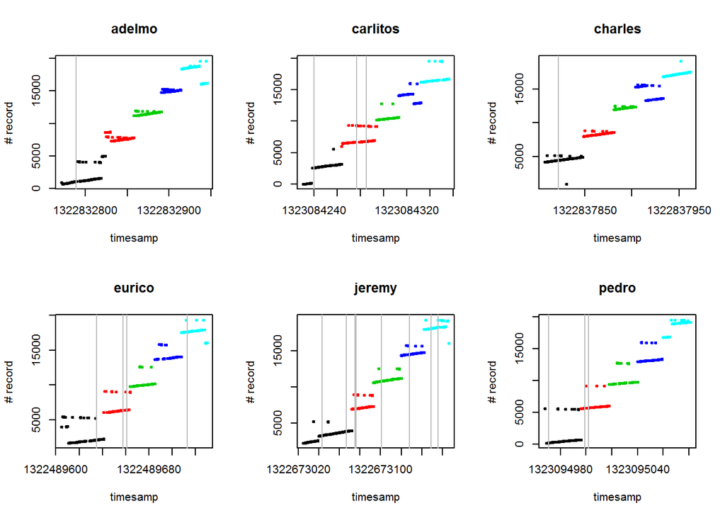

```r
# Choose unique user names
usrs <- sort(unique(training$user_name))
par(mfrow=c(2,3))
for (i in 1:6) {
    # Ploting user data separatedly
    usr = usrs[i]
    tr2 <- training_cleaned[training_cleaned$user_name==usr,]
    plot(tr2$raw_timestamp_part_1,
         tr2$X,
         col=tr2$classe,
         pch=19,
         cex=.5,
         xlab = "timesamp",
         ylab = "# record",
         main = usr)

    # Plot a vertical line for each testing record at the related timestamp
    tt2 <- testing_cleaned[testing_cleaned$user_name==usr,]
    abline(v=tt2$raw_timestamp_part_1, col='gray')
}
```

Following, we are going to model this pattern with the classification *Recursive Partitioning and Regression Trees* algorithm.

```r
# Modeling with rpart method for 1 predictor
modRPart <- train(classe ~ raw_timestamp_part_1, method="rpart", data = training_cleaned)
modRPart
```

```
## CART
##
## 19622 samples
##     1 predictor
##     5 classes: 'A', 'B', 'C', 'D', 'E'
##
## No pre-processing
## Resampling: Bootstrapped (25 reps)
## Summary of sample sizes: 19622, 19622, 19622, 19622, 19622, 19622, ...
## Resampling results across tuning parameters:
##
##   cp          Accuracy   Kappa
##   0.00000000  0.9919777  0.9898498
##   0.01036177  0.9919988  0.9898771
##   0.02072354  0.8507488  0.7919714
##
## Accuracy was used to select the optimal model using  the largest value.
## The final value used for the model was cp = 0.01036177.
```

The accuracy for this model is *0.99*. Let’s predict the *classe* values:

```r
predRPart <- predict(modRPart, testing_cleaned)
table(testing_cleaned$user_name, predRPart)
```

```
##           predRPart
##            A B C D E
##   adelmo   1 0 0 0 0
##   carlitos 1 2 0 0 0
##   charles  1 0 0 0 0
##   eurico   1 2 0 0 1
##   jeremy   2 2 1 1 2
##   pedro    1 2 0 0 0
```

These are the same shown in the previous plot.

## Modeling without timestamp variables

We start by choosing the movement variables plus *user_name*, *classe* and *X*.

```r
dataMov <- training_cleaned[,grep('^(?:.*(?:gyros|accel|magnet).*$|user_name|classe|X)$',
                                  names(training_cleaned))]
```

### Modeling by k-Nearest Neighbourgh

```r
# Control
ctrl <- trainControl(method="repeatedcv",
                     number=10,
                     repeats = 3)

# Model
modKnn <- train(classe ~ .,
                data = dataMov,
                method = "knn",
                trControl = ctrl,
                preProcess = c("center","scale"),
                tuneLength = 2)

#Result
modKnn
```

```
## k-Nearest Neighbors
##
## 19622 samples
##    42 predictor
##     5 classes: 'A', 'B', 'C', 'D', 'E'
##
## Pre-processing: centered (46), scaled (46)
## Resampling: Cross-Validated (10 fold, repeated 3 times)
## Summary of sample sizes: 17660, 17660, 17661, 17659, 17660, 17660, ...
## Resampling results across tuning parameters:
##
##   k  Accuracy   Kappa
##   5  0.9878708  0.9846562
##   7  0.9814661  0.9765517
##
## Accuracy was used to select the optimal model using  the largest value.
## The final value used for the model was k = 5.
```

The accuracy of this model is 0.98. The prediction is the following:

```r
# Prediction
predKnn <- predict(modKnn, testing_cleaned)
table(testing_cleaned$user_name, predKnn)
```

```
##           predKnn
##            A B C D E
##   adelmo   1 0 0 0 0
##   carlitos 2 1 0 0 0
##   charles  1 0 0 0 0
##   eurico   2 2 0 0 0
##   jeremy   5 1 1 0 1
##   pedro    1 2 0 0 0
```

And this is the comparison with the 1-variable prediction:

```r
confusionMatrix(predKnn, predRPart)
```

```
## Confusion Matrix and Statistics
##
##           Reference
## Prediction A B C D E
##          A 7 2 1 1 1
##          B 0 6 0 0 0
##          C 0 0 0 0 1
##          D 0 0 0 0 0
##          E 0 0 0 0 1
##
## Overall Statistics
##
##                Accuracy : 0.7
##                  95% CI : (0.4572, 0.8811)
##     No Information Rate : 0.4
##     P-Value [Acc > NIR] : 0.006466
##
##                   Kappa : 0.5455
##  Mcnemar's Test P-Value : NA
##
## Statistics by Class:
##
##                      Class: A Class: B Class: C Class: D Class: E
## Sensitivity            1.0000   0.7500   0.0000     0.00   0.3333
## Specificity            0.6154   1.0000   0.9474     1.00   1.0000
## Pos Pred Value         0.5833   1.0000   0.0000      NaN   1.0000
## Neg Pred Value         1.0000   0.8571   0.9474     0.95   0.8947
## Prevalence             0.3500   0.4000   0.0500     0.05   0.1500
## Detection Rate         0.3500   0.3000   0.0000     0.00   0.0500
## Detection Prevalence   0.6000   0.3000   0.0500     0.00   0.0500
## Balanced Accuracy      0.8077   0.8750   0.4737     0.50   0.6667
```

### Modeling by Random Forest

```r
# Model
metric <- "Accuracy"
mtry <- sqrt(ncol(dataMov))
tunegrid <- expand.grid(.mtry=mtry)
modRf <- train(classe ~ .,
               data = dataMov,
               method = "rf",
               trControl = ctrl,
               tuneGrid=tunegrid)
modRf
```

```
## Random Forest
##
## 19622 samples
##    42 predictor
##     5 classes: 'A', 'B', 'C', 'D', 'E'
##
## No pre-processing
## Resampling: Cross-Validated (10 fold, repeated 3 times)
## Summary of sample sizes: 17659, 17660, 17660, 17659, 17660, 17660, ...
## Resampling results:
##
##   Accuracy  Kappa
##   0.999983  0.9999785
##
## Tuning parameter 'mtry' was held constant at a value of 6.557439
```

The accuracy of this model is 1. The prediction is the following:

```r
# Prediction
predRf <- predict(modRf, testing_cleaned)
table(testing_cleaned$user_name, predRf)
```

```
##           predRf
##            A B C D E
##   adelmo   1 0 0 0 0
##   carlitos 3 0 0 0 0
##   charles  1 0 0 0 0
##   eurico   4 0 0 0 0
##   jeremy   8 0 0 0 0
##   pedro    3 0 0 0 0
```

We finish the analysis of this model by comparing it with the 1-variable prediction:

```r
confusionMatrix(predRf, predRPart)
```

```
## Confusion Matrix and Statistics
##
##           Reference
## Prediction A B C D E
##          A 7 8 1 1 3
##          B 0 0 0 0 0
##          C 0 0 0 0 0
##          D 0 0 0 0 0
##          E 0 0 0 0 0
##
## Overall Statistics
##
##                Accuracy : 0.35
##                  95% CI : (0.1539, 0.5922)
##     No Information Rate : 0.4
##     P-Value [Acc > NIR] : 0.75
##
##                   Kappa : 0
##  Mcnemar's Test P-Value : NA
##
## Statistics by Class:
##
##                      Class: A Class: B Class: C Class: D Class: E
## Sensitivity              1.00      0.0     0.00     0.00     0.00
## Specificity              0.00      1.0     1.00     1.00     1.00
## Pos Pred Value           0.35      NaN      NaN      NaN      NaN
## Neg Pred Value            NaN      0.6     0.95     0.95     0.85
## Prevalence               0.35      0.4     0.05     0.05     0.15
## Detection Rate           0.35      0.0     0.00     0.00     0.00
## Detection Prevalence     1.00      0.0     0.00     0.00     0.00
## Balanced Accuracy        0.50      0.5     0.50     0.50     0.50
```

### Modeling by Recursive Partitioning and Regression Trees

```r
# Model
metric <- "Accuracy"
mtry <- sqrt(ncol(dataMov))
tunegrid <- expand.grid(.mtry=mtry)
modRPartAll <- train(classe ~ .,
               data = dataMov,
               method = "rpart")
modRPartAll
```

```
## CART
##
## 19622 samples
##    42 predictor
##     5 classes: 'A', 'B', 'C', 'D', 'E'
##
## No pre-processing
## Resampling: Bootstrapped (25 reps)
## Summary of sample sizes: 19622, 19622, 19622, 19622, 19622, 19622, ...
## Resampling results across tuning parameters:
##
##   cp         Accuracy   Kappa
##   0.2436975  0.7440293  0.6748909
##   0.2568722  0.5935120  0.4817164
##   0.2704031  0.3833613  0.1716187
##
## Accuracy was used to select the optimal model using  the largest value.
## The final value used for the model was cp = 0.2436975.
```

The accuracy of this model is 0.74. The prediction is the following:

```r
# Prediction
predRPartAll <- predict(modRPartAll, testing_cleaned)
table(testing_cleaned$user_name, predRPartAll)
```

```
##           predRPartAll
##            A B C D E
##   adelmo   1 0 0 0 0
##   carlitos 3 0 0 0 0
##   charles  1 0 0 0 0
##   eurico   4 0 0 0 0
##   jeremy   8 0 0 0 0
##   pedro    3 0 0 0 0
```

Again, we compare it with the 1-variable prediction:

```r
confusionMatrix(predRPartAll, predRPart)
```

```
## Confusion Matrix and Statistics
##
##           Reference
## Prediction A B C D E
##          A 7 8 1 1 3
##          B 0 0 0 0 0
##          C 0 0 0 0 0
##          D 0 0 0 0 0
##          E 0 0 0 0 0
##
## Overall Statistics
##
##                Accuracy : 0.35
##                  95% CI : (0.1539, 0.5922)
##     No Information Rate : 0.4
##     P-Value [Acc > NIR] : 0.75
##
##                   Kappa : 0
##  Mcnemar's Test P-Value : NA
##
## Statistics by Class:
##
##                      Class: A Class: B Class: C Class: D Class: E
## Sensitivity              1.00      0.0     0.00     0.00     0.00
## Specificity              0.00      1.0     1.00     1.00     1.00
## Pos Pred Value           0.35      NaN      NaN      NaN      NaN
## Neg Pred Value            NaN      0.6     0.95     0.95     0.85
## Prevalence               0.35      0.4     0.05     0.05     0.15
## Detection Rate           0.35      0.0     0.00     0.00     0.00
## Detection Prevalence     1.00      0.0     0.00     0.00     0.00
## Balanced Accuracy        0.50      0.5     0.50     0.50     0.50
```

## Conclusion

Looking at the results obtained with the dataset without timestamp variables, the author concludes that the better the data knowledge is, the more accurated the model could be.

Due to the fact that the records have information about the user movements allong the time, it is easy to guess that although the user was doing the exercise in differents ways, at some moment the devices records could be the same or very close; this is in my opinion the main reason because the results taking into account the timestamp variable are so far from the others.